# STATS 506 - Homework 2

Author

Vincent Weng

### Problem 1 - Dice Game

Part (A) - Version 1: Implement this game using a loop.

```r
#' Dice Game Version 1: Using a loop
#' @description Plays a dice game
#' @param num_rolls: Number of dice to roll
#' @return total_winnings: Total winnings after accumulating wins and losses
play_dice1 <- function(num_rolls) {
  total_winnings <- 0 # initialize total winnings at 0 before rolling

  # simulates 'num_rolls' times from 1 to 6 with replacement
  roll <- sample(1:6, num_rolls, replace = TRUE)

  # loops through each singular roll
  for (i in 1:num_rolls) {
    total_winnings <- total_winnings - 2 # subtracts $2 to roll each time
    if (roll[i] == 3) {
      total_winnings <- total_winnings + 6 # if the roll is 3, you win $6
    } else if (roll[i] == 5) {
      total_winnings <- total_winnings + 10 # if you roll a 5, you win $10
    }
  }
  return(total_winnings)
}
```

Part (A) - Version 2: Implement this game using built-in R vectorized functions.

```r
#' Dice Game Version 2: Using built-in R vectorized functions
#' @description Plays a dice game
#' @param num_rolls: Number of dice to roll
#' @return total_winnings: Total winnings after accumulating wins and losses
play_dice2 <- function(num_rolls) {
  # simulates 'num_rolls' times from 1 to 6 with replacement
  rolls <- sample(1:6, num_rolls, replace = TRUE)

  # calculate total winnings: 2 times the roll value if it's 3 or 5, otherwise 0.
  total_winnings <- ifelse(rolls == 3 | rolls == 5, 2 * rolls, 0)

  # sums total from winning rolls and subtracting $2 for each roll
  total_winnings <- sum(total_winnings) - (2*num_rolls)

  return(total_winnings)
}
```

Part (A) - Version 3: Implement this by rolling all the dice into one and collapsing the die rolls into a single table()

```r
#' Dice Game Version 3: By rolling all dice into one and collapsing die rolls into single table()
#' @description Plays a dice game
#' @param num_rolls: Number of dice to roll
#' @return total_winnings: Total winnings after accumulating wins and losses
play_dice3 <- function(num_rolls) {
  # table of count occurrences of each dice roll (1 to 6) over 'num_rolls'
  dice_rolls <- table(factor(sample(1:6, num_rolls, replace=TRUE), levels=1:6))

  # total winnings: $6 for 3 rolled, 10$ for 5 rolled, minus 2 per roll
  table <- dice_rolls[3]*6 + dice_rolls[5]*10 - 2*num_rolls
  return(table)
}
```

Part (A) - Version 4: Implement this game by using one of the “apply” functions

```r
#' Dice Game Version 4: By using one of the “apply” functions
#' @description Plays a dice game
#' @param num_rolls: Number of dice to roll
#' @return total_winnings: Total winnings after accumulating wins and losses
play_dice4 <- function(num_rolls) {
  # simulates 'num_rolls' times from 1 to 6 with replacement
  dice_rolls <- sample(1:6, num_rolls, replace=TRUE)

  # calculate total winnings: -2 for each roll, plus winnings based on rolled values
  return(-2*num_rolls + sum(vapply(dice_rolls, function(roll) {
    # return $6 for 3 rolled and $10 for 5 rolled
    if (roll == 3 | roll == 5) {
      return(2*roll)
    } else { # otherwise, return 0 for that roll
      return(0)
    }
  }, 1))) # vapply returns vector of winnings for each roll
}
```

Part (B) - Demonstrate that all versions work. Do so by running each a few times, once with an input a 3, and once with an input of 3,000

```r
cat(
  "Results for play_dice1:\n",
  "Total winnings with 3 rolls:", play_dice1(3), "\n",
  "Total winnings with 3000 rolls:", play_dice1(3000), "\n\n",

  "Results for play_dice2:\n",
  "Total winnings with 3 rolls:", play_dice2(3), "\n",
  "Total winnings with 3000 rolls:", play_dice2(3000), "\n\n",

  "Results for play_dice3:\n",
  "Total winnings with 3 rolls:", play_dice3(3), "\n",
  "Total winnings with 3000 rolls:", play_dice3(3000), "\n\n",

  "Results for play_dice4:\n",
  "Total winnings with 3 rolls:", play_dice4(3), "\n",
  "Total winnings with 3000 rolls:", play_dice4(3000), "\n"
)
```

```
Results for play_dice1:
 Total winnings with 3 rolls: 14
 Total winnings with 3000 rolls: 2006

 Results for play_dice2:
 Total winnings with 3 rolls: 10
 Total winnings with 3000 rolls: 2250

 Results for play_dice3:
 Total winnings with 3 rolls: 10
 Total winnings with 3000 rolls: 1760

 Results for play_dice4:
 Total winnings with 3 rolls: 14
 Total winnings with 3000 rolls: 1888
```

Part (C) - Demonstrate that the four versions give the same result. Test with inputs 3 and 3,000. (You will need to add a way to control the randomization.)

```r
#' Dice Game Version 1: Using a loop
#' @description Plays a dice game
#' @param num_rolls: Number of dice to roll
#' @param seed: Sets a seed (NULL if not provided)
#' @return total_winnings: Total winnings after accumulating wins and losses
play_dice1 <- function(num_rolls, seed = NULL) {
  set.seed(seed) # sets the seed
  total_winnings <- 0 # initialize total winnings at 0 before rolling

  # simulates 'num_rolls' times from 1 to 6 with replacement
  roll <- sample(1:6, num_rolls, replace = TRUE)

  # loops through each singular roll
  for (i in 1:num_rolls) {
    total_winnings <- total_winnings - 2 # subtracts $2 to roll each time
    if (roll[i] == 3) {
      total_winnings <- total_winnings + 6 # if the roll is 3, you win $6
    } else if (roll[i] == 5) {
      total_winnings <- total_winnings + 10 # if you roll a 5, you win $10
    }
  }
  return(total_winnings)
}


#' Dice Game Version 2: Using built-in R vectorized functions
#' @description Plays a dice game
#' @param num_rolls: Number of dice to roll
#' @return total_winnings: Total winnings after accumulating wins and losses
play_dice2 <- function(num_rolls, seed = NULL) {
  set.seed(seed) # sets the seed

  # simulates 'num_rolls' times from 1 to 6 with replacement
  rolls <- sample(1:6, num_rolls, replace = TRUE)

  # calculate total winnings: 2 times the roll value if it's 3 or 5, otherwise 0.
  total_winnings <- ifelse(rolls == 3 | rolls == 5, 2 * rolls, 0)

  # sums total from winning rolls and subtracting $2 for each roll
  total_winnings <- sum(total_winnings) - (2*num_rolls)

  return(total_winnings)
}


#' Dice Game Version 3: By rolling all dice into one and collapsing die rolls into single table()
#' @description Plays a dice game
#' @param num_rolls: Number of dice to roll
#' @return total_winnings: Total winnings after accumulating wins and losses
play_dice3 <- function(num_rolls, seed = NULL) {
  set.seed(seed) # sets the seed

  # table of count occurrences of each dice roll (1 to 6) over 'num_rolls'
  dice_rolls <- table(factor(sample(1:6, num_rolls, replace=TRUE), levels=1:6))

  # total winnings: $6 for 3 rolled, 10$ for 5 rolled, minus 2 per roll
  table <- dice_rolls[3]*6 + dice_rolls[5]*10 - 2*num_rolls
  return(table)
}


#' Dice Game Version 4: By using one of the “apply” functions
#' @description Plays a dice game
#' @param num_rolls: Number of dice to roll
#' @return total_winnings: Total winnings after accumulating wins and losses
play_dice4 <- function(num_rolls, seed = NULL) {
  set.seed(seed) # sets the seed

  # simulates 'num_rolls' times from 1 to 6 with replacement
  dice_rolls <- sample(1:6, num_rolls, replace=TRUE)

  # calculate total winnings: -2 for each roll, plus winnings based on rolled values
  return(-2*num_rolls + sum(vapply(dice_rolls, function(roll) {
    # return $6 for 3 rolled and $10 for 5 rolled
    if (roll == 3 | roll == 5) {
      return(2*roll)
    } else { # otherwise, return 0 for that roll
      return(0)
    }
  }, 1))) # vapply returns vector of winnings for each roll
}

cat(
  "Results for play_dice1:\n",
  "Total winnings with 3 rolls:", play_dice1(3, seed = 111), "\n",
  "Total winnings with 3000 rolls:", play_dice1(3000, seed = 111), "\n\n",

  "Results for play_dice2:\n",
  "Total winnings with 3 rolls:", play_dice2(3, seed = 111), "\n",
  "Total winnings with 3000 rolls:", play_dice2(3000, seed = 111), "\n\n",

  "Results for play_dice3:\n",
  "Total winnings with 3 rolls:", play_dice3(3, seed = 111), "\n",
  "Total winnings with 3000 rolls:", play_dice3(3000, seed = 111), "\n\n",

  "Results for play_dice4:\n",
  "Total winnings with 3 rolls:", play_dice4(3, seed = 111), "\n",
  "Total winnings with 3000 rolls:", play_dice4(3000, seed = 111), "\n"
)
```

```
Results for play_dice1:
 Total winnings with 3 rolls: 0
 Total winnings with 3000 rolls: 1918

 Results for play_dice2:
 Total winnings with 3 rolls: 0
 Total winnings with 3000 rolls: 1918

 Results for play_dice3:
 Total winnings with 3 rolls: 0
 Total winnings with 3000 rolls: 1918

 Results for play_dice4:
 Total winnings with 3 rolls: 0
 Total winnings with 3000 rolls: 1918
```

Part(D) - Use the microbenchmark package to clearly demonstrate the speed of the implementations. Compare performance with a low input (1,000) and a large input (100,000). Discuss the results

```r
library(microbenchmark)
microbenchmark(loop = play_dice1(1000, seed = 111),
               vectorized = play_dice2(1000, seed = 111),
               table = play_dice3(1000, seed = 111),
               apply = play_dice3(1000, seed = 111))
```

```
Unit: microseconds
       expr    min      lq     mean  median      uq     max neval
       loop 64.780 65.5385 67.75742 66.2765 68.2240 103.730   100
 vectorized 44.280 45.9405 48.72071 48.0315 49.5895  68.757   100
      table 78.105 80.0525 84.31035 82.6560 85.2185 130.544   100
      apply 77.695 80.5650 85.31239 83.4350 87.7400 152.848   100
```

```r
microbenchmark(loop = play_dice1(100000, seed = 111),
               vectorized = play_dice2(100000, seed = 111),
               table = play_dice3(100000, seed = 111),
               apply = play_dice3(100000, seed = 111))
```

```
Unit: milliseconds
       expr      min       lq     mean   median       uq      max neval
       loop 6.199979 6.227224 6.320231 6.249855 6.294176 8.768752   100
 vectorized 3.946209 4.198175 4.417821 4.243479 4.338969 6.219167   100
      table 5.218521 5.430060 5.571476 5.465956 5.535123 7.181724   100
      apply 5.213068 5.431947 5.617359 5.481782 5.567308 7.612265   100
```

For low input of 1000, vectorized is by far the fastest. Then using a loop is the next fastest, followed by table(). Finally, vapply() looks like to be the slowest, but not that much slower than table() (since the difference is minimal).

In conclusion, it looks like vectorized has the fastest performance no matter the input size. Furthermore, it looks like table() and vapply() have pretty similar speeds that was consistent for both the low and large input. Finally, using a loop seems seems to be slower when compared to table() and vapply() after the input size increased substantially.

Part(E) - Do you think this is a fair game? Defend your decision with evidence based upon a Monte Carlo simulation.

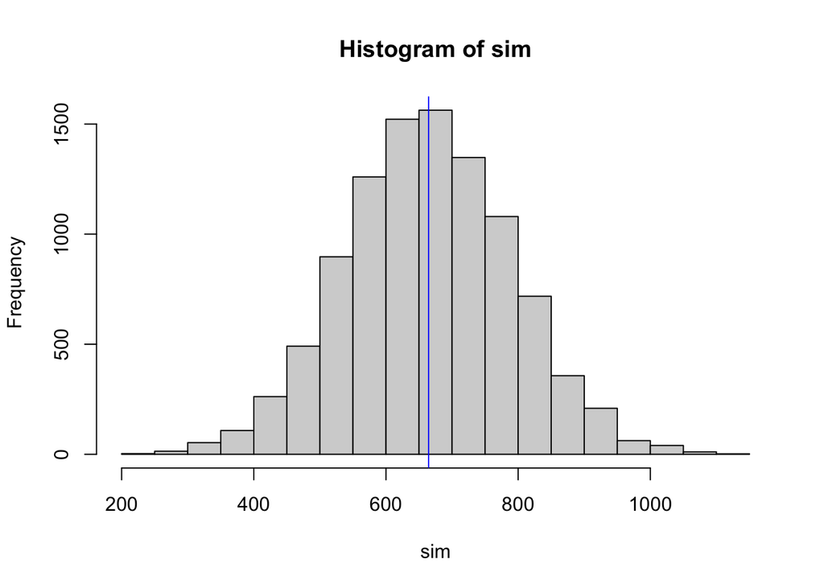

```r
reps <- 10000 # set number of repetitions for simulation

# initialize vector that stores each simulation run
sim <- vector(length = reps)

# loop through each rep to simulate dice game
for (i in 1:reps) {
  # store result with 1000 rolls in the sim vector
  sim[i] <- play_dice1(1000)
}

# graphs histogram to visualize the distribution of total winnings
hist(sim)

# Add a vertical line to the histogram at the mean of the simulated results
abline(v = mean(sim), col = 'blue')
```

This not a fair game, because the Monte Carlo simluation shows that the expected value (average outcome) of the game is not equal or close to zero.

### Problem 2 - Linear Regression

Part(A) - The names of the variables in this data are way too long. Rename the columns of the data to more reasonable lengths.

```r
cars_data <- read.csv("cars.csv") # read in cars dataframe

# rename column name of each variable
colnames(cars_data) <- c("dim_height", "dim_length", "dim_width", "eng_drive_line", "eng_type", "eng_hybrid", "eng_num_gears", "eng_transmission", "fuel_city_mpg", "fuel_type", "fuel_highway_mpg", "id_class", "id", "id_make", "id_model_year", "id_year", "eng_horsepower", "eng_torque")
```

Part(B) - Restrict the data to cars whose Fuel Type is “Gasoline”.

```r
# restrict cars_data to cars whose fuel type is “Gasoline”
gasoline_cars <- cars_data[cars_data$fuel_type == "Gasoline", ]
```

Part(C) - Examine the distribution of highway gas mileage. Consider whether a transformation could be used. If so, generate the transformed variable and use this variable going forward. If not, provide a short justification.

```r
# highway gas mileage of 223 was removed (outlier)
gasoline_cars <- gasoline_cars[gasoline_cars$fuel_highway_mpg < 50, ]

# showing outlier has been removed
summary(gasoline_cars$fuel_highway_mpg)
```

```
   Min. 1st Qu.  Median    Mean 3rd Qu.    Max.
  13.00   21.00   25.00   24.92   28.00   42.00
```

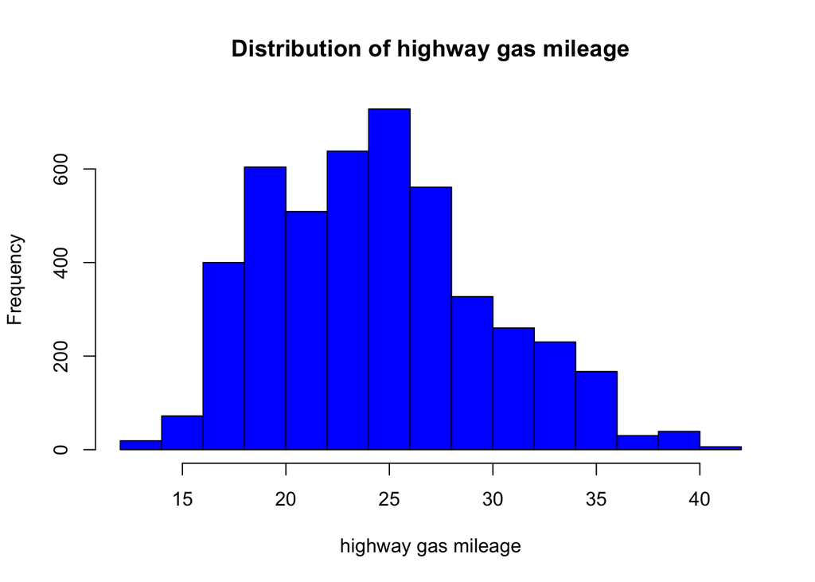

```r
# showing distribution of highway MPG
hist(gasoline_cars$fuel_highway_mpg,
     main = "Distribution of highway gas mileage",
     xlab = "highway gas mileage",
     col = "blue")
```

There was an outlier of fuel_highway_mpg that was equal to 223, so I removed that from the data. Furthermore, the histogram shows that the highway MPG is pretty close to representing a normal distribution, so no transformation is needed.

Part(D) - Fit a linear regression model predicting MPG on the highway. The predictor of interest is torque. Control for:

- The horsepower of the engine
- All three dimensions of the car
- The year the car was released, as a categorical variable.

Briefly discuss the estimated relationship between torque and highway MPG. Be precise about the interpretation of the estimated coefficient.

```r
# running linear regression model with predictor torque and controlling for the other variables
model <- lm(fuel_highway_mpg ~ eng_torque + eng_horsepower + dim_length +
              dim_width + dim_height + as.factor(id_year), data = gasoline_cars)

# showing summary of the regression results
summary(model)
```

```
Call:
lm(formula = fuel_highway_mpg ~ eng_torque + eng_horsepower +
    dim_length + dim_width + dim_height + as.factor(id_year),
    data = gasoline_cars)

Residuals:
     Min       1Q   Median       3Q      Max
-10.9695  -2.4981  -0.3671   2.4164  19.8079

Coefficients:
                         Estimate Std. Error t value Pr(>|t|)
(Intercept)            32.4107371  0.5486291  59.076   <2e-16 ***
eng_torque             -0.0517480  0.0016727 -30.937   <2e-16 ***
eng_horsepower          0.0171254  0.0017290   9.905   <2e-16 ***
dim_length              0.0011433  0.0006710   1.704   0.0885 .
dim_width              -0.0008147  0.0006867  -1.186   0.2356
dim_height              0.0104613  0.0008555  12.228   <2e-16 ***
as.factor(id_year)2010 -0.4497677  0.5138721  -0.875   0.3815
as.factor(id_year)2011  0.0709912  0.5130245   0.138   0.8899
as.factor(id_year)2012  1.2925749  0.5170481   2.500   0.0125 *
---
Signif. codes:  0 '***' 0.001 '**' 0.01 '*' 0.05 '.' 0.1 ' ' 1

Residual standard error: 3.494 on 4581 degrees of freedom
Multiple R-squared:  0.5626,    Adjusted R-squared:  0.5618
F-statistic: 736.5 on 8 and 4581 DF,  p-value: < 2.2e-16
```

Torque and highway MPG has significant negative relationship. This means that on average, the model predics that higher torque yields a lower highway MPG. This is statistically significant, because the p-value is less than 0.05.

Part(E) - It seems reasonable that there may be an interaction between torque and horsepower. Refit the model (with lm) and generate an interaction plot, showing how the relationship between torque and MPG changes as horsepower changes. Choose reasonable values of torque, and show lines for three different reasonable values of horsepower.

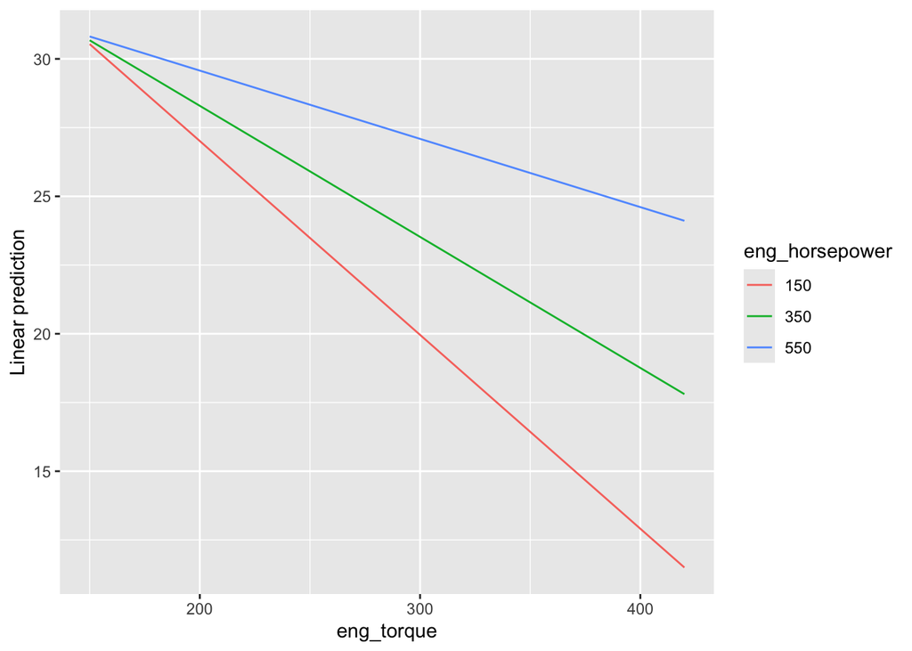

```r
library(interactions)
library(emmeans)
# lm() for generating interaction plot between torque and highway MPG, as horsepower changes
model <- lm(fuel_highway_mpg ~ eng_torque*eng_horsepower + dim_length +
              dim_width + dim_height + as.factor(id_year), data = gasoline_cars)

# using emmip()
emmip(model, eng_horsepower ~ eng_torque,
      at = list(eng_horsepower =
                c(150, 350, 550),
                eng_torque = c(150, 260, 420)))
```

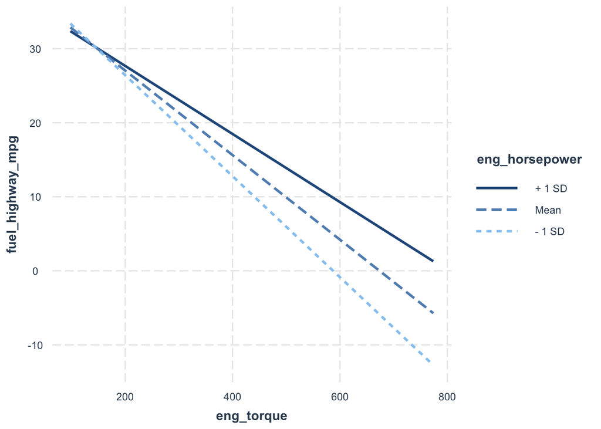

```r
# using interact_plot()
interact_plot(model, pred = eng_torque, modx = eng_horsepower,
              at = list (id_year = 2010), data = gasoline_cars)
```

Part(F) - Calculate $\hat{\beta}$ from d. manually (without using lm) by first creating a proper design matrix, then using matrix algebra to estimate $\beta$. Confirm that you get the same result as lm did prior.

```r
# using lm() to be compared to later for checking purposes
model <- lm(fuel_highway_mpg ~ eng_torque*eng_horsepower + dim_length +
              dim_width + dim_height + as.factor(id_year), data = gasoline_cars)

# estimating beta using matrix algebra
X <- model.matrix(fuel_highway_mpg ~ eng_torque*eng_horsepower +
                    dim_length + dim_width + dim_height + as.factor(id_year),
                    data = gasoline_cars)

y <- gasoline_cars$fuel_highway_mpg
X_transpose <- t(X)
X_transpose_X <- X_transpose %*% X
X_transpose_X_inverse <- solve(X_transpose_X)
X_transpose_y <- X_transpose %*% y
beta_hat <- X_transpose_X_inverse %*% X_transpose_y

beta_hat
```

```
                                  [,1]
(Intercept)               42.471008512
eng_torque                -0.087656308
eng_horsepower            -0.016438826
dim_length                 0.001189191
dim_width                 -0.001665871
dim_height                 0.007060713
as.factor(id_year)2010    -0.560374864
as.factor(id_year)2011    -0.029665866
as.factor(id_year)2012     1.184873242
eng_torque:eng_horsepower  0.000114224
```

```r
model
```

```
Call:
lm(formula = fuel_highway_mpg ~ eng_torque * eng_horsepower +
    dim_length + dim_width + dim_height + as.factor(id_year),
    data = gasoline_cars)

Coefficients:
              (Intercept)                 eng_torque
               42.4710085                 -0.0876563
           eng_horsepower                 dim_length
               -0.0164388                  0.0011892
                dim_width                 dim_height
               -0.0016659                  0.0070607
   as.factor(id_year)2010     as.factor(id_year)2011
               -0.5603749                 -0.0296659
   as.factor(id_year)2012  eng_torque:eng_horsepower
                1.1848732                  0.0001142
```

From the above results, I get the same results as lm().